# Analyse_Ressenties_Reddit

PIERRON Marie_ BACHER Quentin

2025-04-23

### Plan

### 1. Introduction

### 2. Méthodologie

```
2.1 Outils utilisé

2.2 Fonctionnement du programme
```

### 3. Sorties des résultats

```
3.1 Graphique de répartition

3.2 Synthèse textuelle
```

### 4. Présentation de l’interface et démonstration

### 5. Conclusion

## 1. Introduction

- Objectif :

Analyser les avis et les ressenties des utilisateurs autour d’un mot clé sur reddit

- Dans quel but ?

Permet de voir si l’opinion des utilisateurs est plutot positive, neutre ou négative concernant un sujet/une personnalité

## 2. Méthodologie

### 2.1 Outils utilisé

- Praw : permet d’accéder aux données Reddit via l’API officielle
- Textblob : pour determiner la polarité d’un texte et déterminer son sentiment
- Plotly : pour générer des graphiques interactifs (jauge de sentiment)
- Gemini : pour générer automatiquement une synthèse textuelle
- Tkinter : pour construire une interface utilisateur

### 2.2 Fonctionnement du programme

### Connexion à l’API Reddit

```r
reddit = praw.Reddit(
    client_id='Mettre ses infos personnels',
    client_secret='Mettre ses infos personnels',
    user_agent='Mettre ses infos personnels',
    username='Mettre ses infos personnels',
    password='Mettre ses infos personnels',
)
```

### Récupère les posts reddit datant de moins de 24h, moins d’une semaine, moins d’un mois

```r
    for post in reddit.subreddit("all").search(mot_cle, sort='new',
        time_filter='day',  limit=int(limite / 3)):
        date_post = datetime.fromtimestamp(post.created_utc,
        timezone.utc)
        age = maintenant - date_post

        info = {
            'titre': post.title,
            'url': post.url,
            'score': post.score,
            'date': date_post.strftime("%Y-%m-%d %H:%M:%S"),
        }

        if age <= timedelta(days=1):
            posts_24h.append(info)

    # Ensuite, les posts plus anciens (jusqu'à un mois)
    for post in reddit.subreddit("all").search(mot_cle, sort='relevance',
        time_filter='month', limit=int(limite * 2 / 3)):
        date_post = datetime.fromtimestamp(post.created_utc, timezone.utc)
        age = maintenant - date_post

        info = {
            'titre': post.title,
            'url': post.url,
            'score': post.score,
            'date': date_post.strftime("%Y-%m-%d %H:%M:%S"),
        }

        if timedelta(days=1) < age <= timedelta(days=7):
            posts_1w.append(info)
        elif timedelta(days=7) < age <= timedelta(days=30):
            posts_1m.append(info)

    return {
        "il_y_a_24h": posts_24h,
        "il_y_a_une_semaine": posts_1w,
        "il_y_a_un_mois": posts_1m
    }
```

### Utilise Textblob qui donne un score à un post (positif (>0), neutre (=0), négatif (<0).)

```r
 sentiments = []
    times = []

    for avis_item in tous_les_avis:
        texte = avis_item.get("titre", "")
        date = avis_item.get("date")
        if texte.strip():
            polarite = TextBlob(texte).sentiment.polarity
            sentiment = "positif" if polarite > 0 else "negatif"
            if polarite < 0 else "neutre"

            sentiments.append(sentiment)

            times.append(date if isinstance(date, datetime)
            else datetime.now())
            print(f" {texte} Polarité : {polarite} {sentiment}")
```

### Synthèse avec Gemini

```r
 genai.configure(api_key="Mettre ses infos personnels")

# Initialisation du modèle Gemini
gemini_model = genai.GenerativeModel("gemini-1.5-pro-latest")

sentiments = []
    times = []

    for avis_item in tous_les_avis:
        texte = avis_item.get("titre", "")
        date = avis_item.get("date")
        if texte.strip():
            polarite = TextBlob(texte).sentiment.polarity
            sentiment = "positif" if polarite > 0 else "negatif" if polarite < 0 else "neutre"
            sentiments.append(sentiment)
            times.append(date if isinstance(date, datetime) else datetime.now())
            print(f" {texte} Polarité : {polarite} {sentiment}")
```

## Mise en place de l’interface utilisateur

- Un champ pour saisir un mot-clé de recherche.
- Un tableau interactif affichant les posts analysés.
- Un onglet affichant le résumé intelligent des résultats, ainsi que le graphique illustrant les avis positifs,négatifs et neutre.
- L’interface permet une utilisation intuitive pour tous les utilisateurs, même sans connaissance technique.

```r
# Interface graphique
class RedditAnalyzerApp:
    def __init__(self, root):
        self.root = root
        self.root.title("Analyseur de Sentiments Reddit")

        # Cadre principal
        main_frame = ttk.Frame(root, padding="10")
        main_frame.pack(fill=tk.BOTH, expand=True)

        # Entrée mot-clé
        ttk.Label(main_frame, text="Mot-clé:").grid(row=0, column=0, sticky=tk.W)
        self.keyword_entry = ttk.Entry(main_frame, width=40)
        self.keyword_entry.grid(row=0, column=1, sticky=tk.EW, padx=5, pady=5)
        self.keyword_entry.insert(0, "Trump")

        # Limite de résultats
        ttk.Label(main_frame, text="Limite:").grid(row=1, column=0, sticky=tk.W)
        self.limit_entry = ttk.Entry(main_frame, width=10)
        self.limit_entry.grid(row=1, column=1, sticky=tk.W, padx=5, pady=5)
        self.limit_entry.insert(0, "1000")

        # Bouton d'analyse
        self.analyze_btn = ttk.Button(main_frame, text="Analyser", command=self.analyze)
        self.analyze_btn.grid(row=2, column=0, columnspan=2, pady=10)

        # Onglets
        self.notebook = ttk.Notebook(main_frame)
        self.notebook.grid(row=3, column=0, columnspan=2, sticky=tk.NSEW)

        # Onglet Résultats
        self.results_tab = ttk.Frame(self.notebook)
        self.notebook.add(self.results_tab, text="Résultats")

        # Onglet Analyse Gemini
        self.gemini_tab = ttk.Frame(self.notebook)
        self.notebook.add(self.gemini_tab, text="Analyse Gemini")

        # Configuration des onglets
        self.setup_results_tab()
        self.setup_gemini_tab()

        # Configurer le redimensionnement
        main_frame.columnconfigure(1, weight=1)
        main_frame.rowconfigure(3, weight=1)

    def setup_results_tab(self):
        # Treeview pour afficher les résultats
        self.tree = ttk.Treeview(self.results_tab, columns=('date', 'titre', 'score', 'sentiment'), show='headings')

        # Configurer les colonnes
        self.tree.heading('date', text='Date')
        self.tree.heading('titre', text='Titre')
        self.tree.heading('score', text='Score')
        self.tree.heading('sentiment', text='Sentiment')

        self.tree.column('date', width=120)
        self.tree.column('titre', width=300)
        self.tree.column('score', width=60)
        self.tree.column('sentiment', width=80)

        # Scrollbar
        scrollbar = ttk.Scrollbar(self.results_tab, orient=tk.VERTICAL, command=self.tree.yview)
        self.tree.configure(yscroll=scrollbar.set)

        # Placement
        self.tree.pack(side=tk.LEFT, fill=tk.BOTH, expand=True)
        scrollbar.pack(side=tk.RIGHT, fill=tk.Y)

    def setup_gemini_tab(self):
        # Zone de texte pour l'analyse Gemini
        self.gemini_text = scrolledtext.ScrolledText(self.gemini_tab, wrap=tk.WORD)
        self.gemini_text.pack(fill=tk.BOTH, expand=True)

    def analyze(self):
        keyword = self.keyword_entry.get()
        limit = int(self.limit_entry.get())

        if not keyword:
            messagebox.showerror("Erreur", "Veuillez entrer un mot-clé")
            return

        try:
            # Appel de vos fonctions existantes
            prompt = generer_prompt_pour_gemini(keyword, limit)
            response = gemini_model.generate_content(prompt)

            # Affichage des résultats
            self.display_results(keyword, limit)
            self.gemini_text.delete(1.0, tk.END)
            self.gemini_text.insert(tk.END, response.text)

        except Exception as e:
            messagebox.showerror("Erreur", f"Une erreur est survenue: {str(e)}")

    def display_results(self, keyword, limit):
        # Effacer les résultats précédents
        for item in self.tree.get_children():
            self.tree.delete(item)

        # Récupérer les avis
        avis = chercher_avis(keyword, limit)
        tous_avis = avis['il_y_a_24h'] + avis['il_y_a_une_semaine'] + avis['il_y_a_un_mois']

        # Ajouter chaque avis au Treeview
        for avis in tous_avis:
            texte = avis['titre']
            polarite = TextBlob(texte).sentiment.polarity
            sentiment = "positif" if polarite > 0 else "negatif" if polarite < 0 else "neutre"

            self.tree.insert('', tk.END, values=(
                avis['date'],
                avis['titre'],
                avis['score'],
                sentiment
            ))
```

## En résumé

Connexion à Reddit avec PRAW pour récupérer des posts selon un mot-clé, sur trois périodes : moins de 24h, une semaine, ou un mois.

Analyse des sentiments avec TextBlob pour classer chaque post en positif, négatif ou neutre.

Génération d’une synthèse automatique avec Google Gemini pour résumer l’évolution des avis dans le temps.

Mise en place d’une interface pour faciliter l’utilisation

## 3. Sortie des résultats

### 3.1 Graphique de répartition

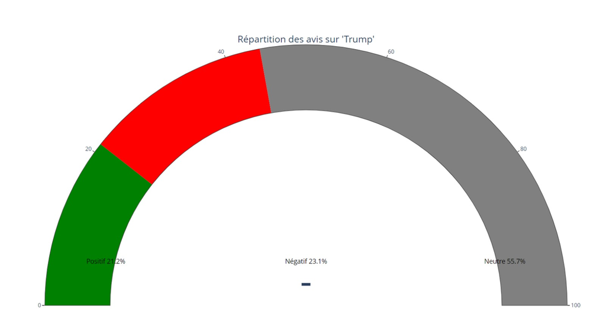

```r
# A. Analyse des sentiments


    # B. Statistiques
    df = Counter(sentiments)
    total = sum(df.values())
    pos_ratio = df["positif"] / total if total else 0
    neg_ratio = df["negatif"] / total if total else 0
    neu_ratio = df["neutre"] / total if total else 0

    print(f"{df['positif']}/{total} avis positifs ({pos_ratio*100:.1f}%)")
    print(f"{df['negatif']}/{total} avis négatifs ({neg_ratio*100:.1f}%)")
    print(f"{df['neutre']}/{total} avis neutres ({neu_ratio*100:.1f}%)")

    # Pourcentages
    pos_pct = pos_ratio * 100
    neg_pct = neg_ratio * 100
    neu_pct = neu_ratio * 100

    # C. Affichage avec jauge et annotations
    fig2 = go.Figure(go.Indicator(
        mode="gauge+number",
        title={"text": f"Répartition des avis sur '{mot_cle}'"},
        gauge={
            "axis": {"range": [0, 100]},
            "steps": [
                {"range": [0, pos_pct], "color": "green"},
                {"range": [pos_pct, pos_pct + neg_pct], "color": "red"},
                {"range": [pos_pct + neg_pct, 100], "color": "gray"}
            ]
        }
    ))

    # Ajout des annotations (trick : les positions x sont approximées visuellement)
    fig2.update_layout(
        annotations=[
            dict(x=0.15, y=0.15, text=f"Positif {pos_pct:.1f}%", showarrow=False, font=dict(color="black", size=14)),
            dict(x=0.50, y=0.15, text=f"Négatif {neg_pct:.1f}%", showarrow=False, font=dict(color="black", size=14)),
            dict(x=0.85, y=0.15, text=f"Neutre {neu_pct:.1f}%", showarrow=False, font=dict(color="black", size=14))
        ]
    )

    fig2.show()

    return prompt
```

## 3.2 Synthèse textuelle

En complément, une synthèse écrite est générée grâce à Google Gemini. Elle explique l’évolution du sentiment au cours des différentes périodes (24h, 1 semaine, 1 mois) et donne une vision plus qualitative de la situation.

## 4. Présentation de l’interface et démonstration

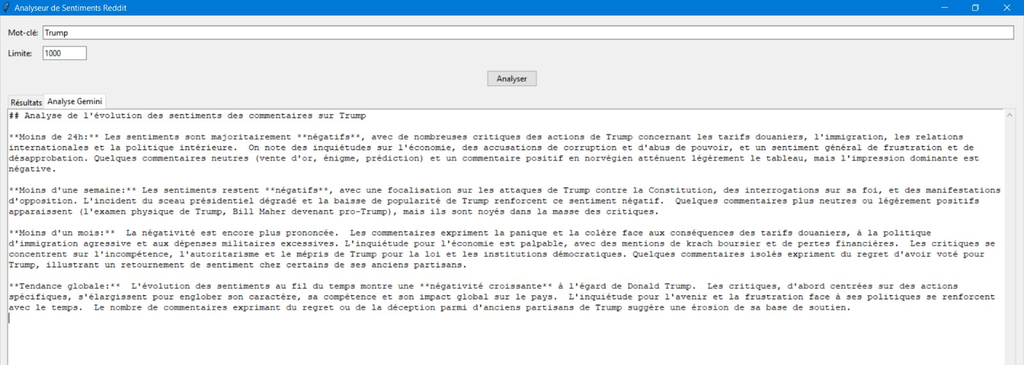

## 5. Conclusion

- Permet d’analyser rapidement de milliers de posts Reddit.
- Synthèse automatisée par IA pour obtenir une synthèse des avis sur un sujet rapidement, et leurs évolutions.
- utilisateur simple et efficace.

Pistes d’amélioration :

- Automatiser la collecte et l’analyse pour obtenir une vision continue dans le temps.
- L’étendre a d’autres réseaux sociaux

## Plan

### 1. Introduction

### 2. Méthodologie

```
2.1 Outils utilisé

2.2 Fonctionnement du programme
```

### 3. Sorties des résultats

```
3.1 Graphique de répartition

3.2 Synthèse textuelle
```

### 4. Présentation de l’interface et démonstration

### 5. Conclusion